# Edison Township School District — NJ School Data Almanac – NJ District Profiles

NJ School Data Almanac

Edison Township School District

MIDDLESEX COUNTY · TRADITIONAL PUBLIC DISTRICT · DFG GH · 16,191 STUDENTS (2026)

16,191

Students

92.1%

4-yr grad rate

68.5%

Gr 3-8 ELA

12.1%

Chronically absent

$15,247

Per pupil

*10 things the data says about Edison Township School District. Every figure is computed from New Jersey Department of Education data via the njschooldata package — nothing is estimated. Comparisons use District Factor Group (DFG) peers (76 districts in DFG GH).*

No. 1 ACHIEVEMENT

On the 2024 NJSLA reading test for grades 3-8, white students in Edison proficient at 46.4% trailed the district average of 68.5% by more than 22 points.

Edison’s overall reading scores look strong: 68.5% of students in grades 3-8 were proficient on the 2024 NJSLA English language arts test. But that headline number is carried almost entirely by one group. Asian students, who make up 63.2% of the district, were proficient at 82.5% — and they pull the whole average up. Strip them out and a very different picture emerges.

The spread is one of the widest a family will find in a single building system: from 82.5% for Asian students down to 6.5% for students currently classified as multilingual learners. As Edison’s non-Asian enrollment grows, the question for the board is whether a district whose average looks healthy can close gaps that the average is actively hiding.

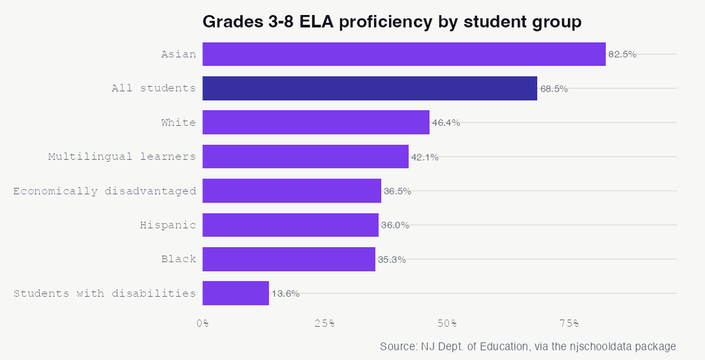

See the underlying data ›

No. 2 ACHIEVEMENT

## Five Years After the Pandemic, Edison’s Reading and Math Scores Have Not Recovered to 2019 Levels

NJSLA ELA proficiency for grades 3-8 fell from 76.2% in 2019 to 68.5% in 2024, while math slid from 62.1% to 53.4% — neither has climbed back.

Before the pandemic, three-quarters of Edison’s third- through eighth-graders read at grade level. In 2019, ELA proficiency stood at 76.2% and math at 62.1%. When testing resumed in 2022, both had dropped sharply: ELA to 68.7% (a 7.5-point fall) and math to 53.5%. Five years on, the rebound the district might have hoped for has not arrived.

The 2023 results offered a flicker of progress, with ELA edging up to 70.7% and math to 55.3%. But 2024 gave it back, settling at 68.5% in ELA and 53.4% in math — essentially where the district landed in the first post-pandemic year, and roughly 8 to 9 points below the 2019 baseline in each subject. The recovery curve other districts have charted is, in Edison, flat.

This is a district that posted 76.2% ELA proficiency as recently as 2019, so the ceiling is not in doubt. The open question is what changes in the next round of testing: whether 2024 marks a stalled plateau or the floor before a climb back toward pre-pandemic norms.

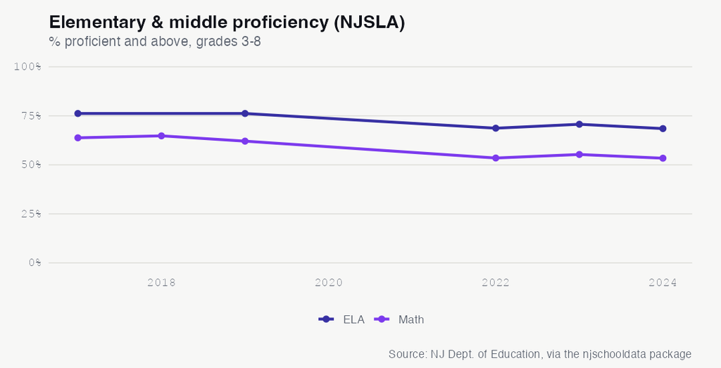

See the underlying data ›

No. 3 GRADUATION

## Edison’s 92% Graduation Rate Ranks in the Bottom Quarter of Its Peer Group, Where the Median Is 96%

A 92.1% four-year graduation rate reads like good news, and on its own it is. But measured against the 76 districts in Edison’s District Factor Group — schools serving demographically and economically similar communities — the rate lands in the 13th percentile, well below the peer median of 96.1%. Where most comparable districts graduate 96 of every 100 students on time, Edison graduates 92.

The gap is not evenly shared. Asian students graduated at 95.0% in 2025, but students with disabilities finished at just 69.7%, multilingual learners at 74.7%, and Hispanic and Black students at 86.0% and 87.0%. The question the board faces is whether the district’s strong test-takers are masking a completion problem concentrated among its most vulnerable seniors.

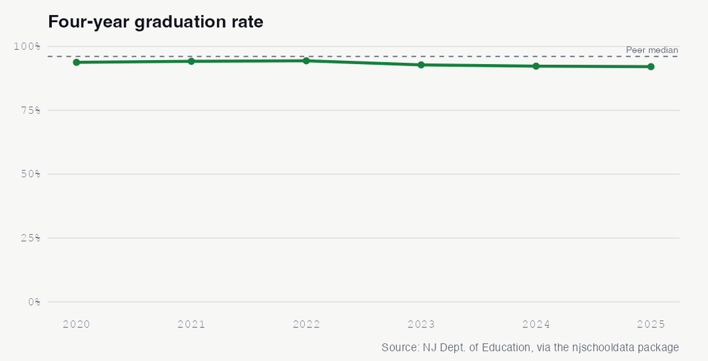

See the underlying data ›

No. 4 FINANCE

## Edison Spends $15,247 Per Student — Roughly $5,200 Below Its Peer Median — Yet Beats the State on AP and IB

Per-pupil spending sits in the 3rd percentile of Edison’s 76-district peer group, while 26.7% of students pass an AP or IB exam against the state’s 23%.

Edison runs one of the leanest budgets among its socioeconomic peers. Its 2024 per-pupil spending of $15,247 placed it in the 3rd percentile of the 76 districts in its District Factor Group, where the median district spent $20,442 — a gap of more than $5,000 per student, multiplied across roughly 16,000 children. The lean budget is not new: Edison ranked among the very lowest spenders in its group for most of the past decade, hitting rank 1 in 2019, 2021 and 2023.

The tension is real: a district outspent by its peers by a wide margin is outscoring the state on its hardest exams. The question is how long a bottom-of-the-group budget can sustain those results as economic need among Edison’s students climbs.

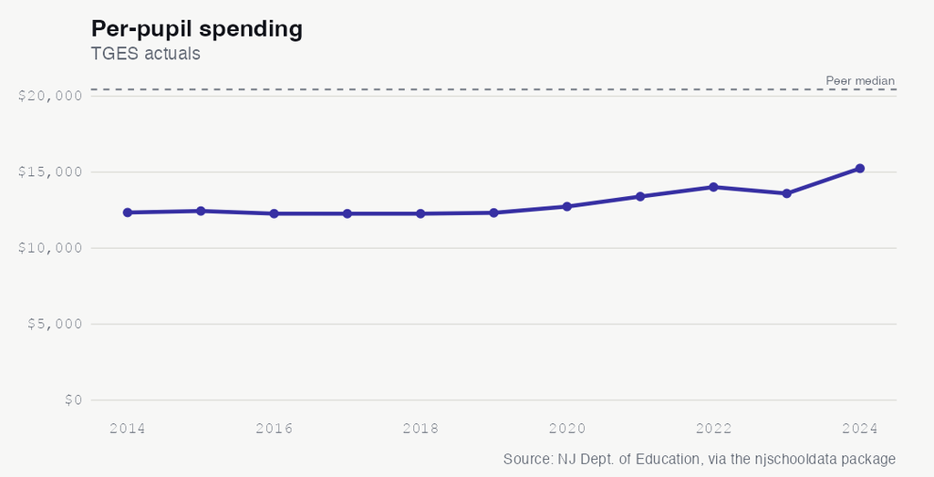

See the underlying data ›

No. 5 ATTENDANCE

## Edison’s Chronic Absenteeism Has Doubled Since 2019, Reaching 12.1% Against a Peer Median of 9.6%

The share of students chronically absent jumped from 5.9% before the pandemic to a 2023 peak of 13%, settling above the peer norm in 2024.

In 2019, Edison had a chronic absenteeism rate of 5.9% — roughly one student in 17 missing 10% or more of the school year. By 2024 that figure had more than doubled to 12.1%, or closer to one in eight. The climb was steep and fast: after a low of 4.2% in the disrupted 2021 year, the rate jumped to 11.5% in 2022 and peaked at 13.0% in 2023 before easing slightly.

The 2024 rate of 12.1% sits above the 9.6% median for Edison’s District Factor Group peers, meaning Edison families are missing school at a higher clip than comparable districts. The slight dip from the 2023 peak hints at stabilization, but the rate remains more than double its pre-pandemic baseline.

Chronic absence tends to track closely with achievement and on-time graduation, both of which have softened in Edison over the same window. The data cannot say which is driving which, leaving the board to ask whether attendance is the lever that moves the rest.

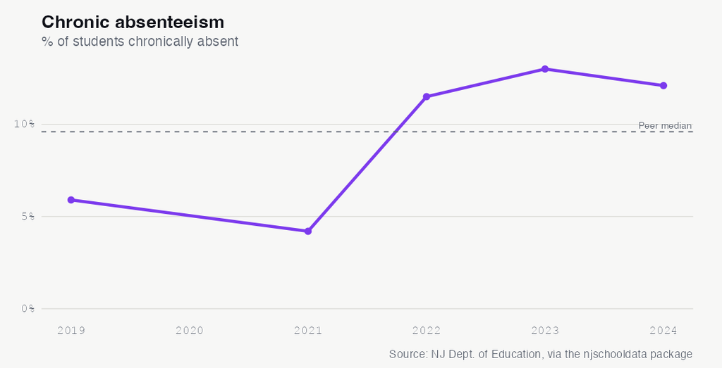

See the underlying data ›

No. 6 EQUITY

## Economic Need in Edison Has Surged: Subsidized-Lunch Eligibility Climbed From 21.9% to 30.2% Since 2015

The share of Edison students eligible for free or reduced-price lunch rose to 30.2% by 2026, while the count of multilingual learners more than tripled.

Edison’s student body is not just changing by race; it is changing by need. In 2015, 21.9% of students (3,216 children) qualified for free or reduced-price lunch. By 2026 that share had risen to 30.2%, or 4,890 students — meaning nearly one in three Edison students now comes from a household that meets the federal low-income threshold, up from roughly one in five a decade earlier.

Language need has grown even faster. Students classified as limited English proficient numbered 354 (2.4%) in 2015; by 2025 the count had jumped to 1,220 (7.3%) before easing to 1,085 (6.7%) in 2026 — roughly a tripling of the share over the period. A district once defined by its affluent, Asian-majority profile is absorbing a rising population of students who need both meal support and language services.

These shifts arrive as per-pupil spending stays near the bottom of Edison’s peer group. The question the budget raises is whether a lean district can scale the supports a higher-need student body requires.

See the underlying data ›

No. 7 EQUITY

## Edison Graduates 7 in 10 Students With Disabilities, a 22-Point Gap Below the District’s Overall Rate

While the district’s 2025 graduation rate was 92.1%, students with disabilities finished at 69.7% and multilingual learners at 74.7%.

Edison’s overall four-year graduation rate of 92.1% in 2025 masks sharp differences in who crosses the stage on time. Students with disabilities graduated at 69.7% — nearly 23 points below the district total and the lowest of any reported subgroup. Multilingual learners followed at 74.7%, and students experiencing homelessness at 82.1% (a cohort of 28).

The contrast at the top of the table is stark. Asian students graduated at 95.0% and female students at 93.9%, both above the district average, while male students (90.4%), Hispanic students (86.0%) and Black students (87.0%) clustered below it. The 25-point spread between Asian students and students with disabilities defines the range.

Graduation is the single clearest measure of whether a school carries a student all the way through, and for Edison’s students with disabilities and multilingual learners, the finish line is markedly farther away. The data leaves open whether targeted senior-year supports could close a gap this wide.

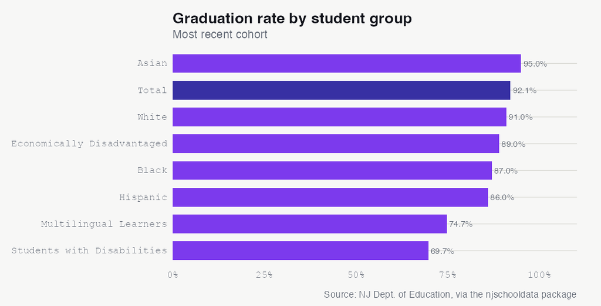

See the underlying data ›

No. 8 ENROLLMENT

## Edison Lost 620 Students in Two Years After Hitting a Record 16,811 in 2024

A decade of nearly uninterrupted growth peaked at 16,811 students in 2024, then reversed to 16,191 by 2026 — a 3.1% single-year drop in the latest count.

The two-year retreat from the 2024 peak totals 620 students. It is too soon to know whether this is the start of a sustained contraction or a short correction after years of expansion, but it ends a growth story that had defined the district since 2015.

Enrollment drives nearly every downstream decision Edison makes, from staffing to building use to state aid. The question the latest numbers raise is whether the 2026 dip is a one-year blip or the leading edge of the demographic plateau that has reached many New Jersey suburbs.

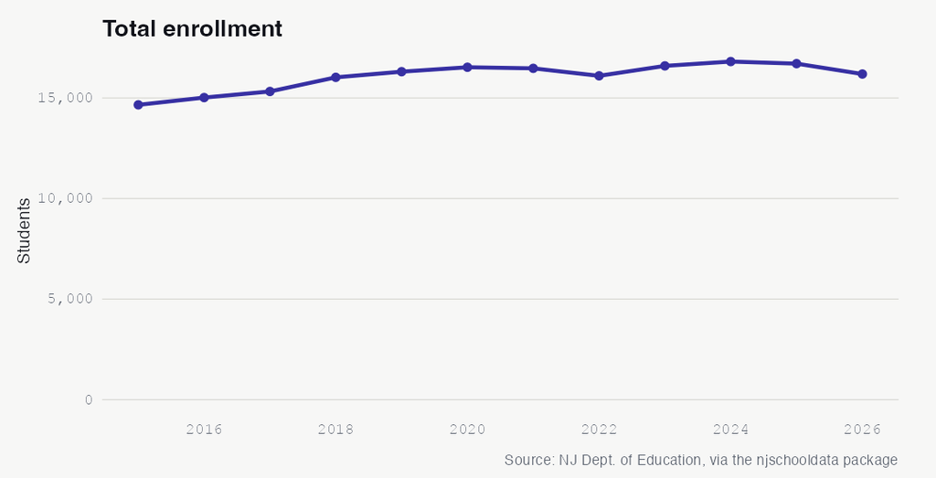

See the underlying data ›

No. 9 DEMOGRAPHICS

## Edison’s White Enrollment Share Has Been Cut Nearly in Half Since 2015, Falling From 19% to 8.6%

An already Asian-majority district grew more diverse on every other axis as the white share dropped 10.4 percentage points in a decade.

Edison was an Asian-majority district a decade ago, and it has only deepened. In 2015, white students made up 19.0% of the district’s 14,659 students; by 2026 that share had fallen to 8.6%, a drop of 10.4 percentage points and the single largest demographic shift in the district over the period. Asian students, already the plurality at 60.5% in 2015, rose to 63.2%, while Hispanic students climbed from 10.5% to 15.1%, a gain of 4.7 points.

What makes Edison unusual is that growth and diversification happened together. Total enrollment rose 10.5% since 2015 even as the white share contracted by more than half. Black enrollment held roughly steady, edging up from 8.6% to 9.0%, while the multiracial share nearly tripled from 1.0% to 2.9%.

The arc is steady rather than sudden, with the white share ticking down almost every year. As the district plans facilities, language services and staffing, the open question is whether the white share levels off near its current single-digit level or keeps falling through the rest of the decade.

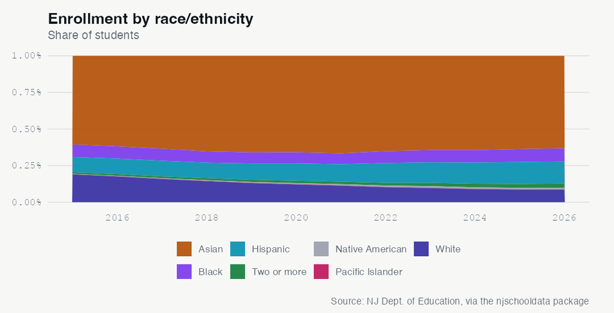

See the underlying data ›

No. 10 ACHIEVEMENT

## Edison’s High Schoolers Pass the State Reading Test at 85.7%, but Math Trails 13 Points Behind at 72.6%

On the 2025 NJGPA graduation-proficiency test, Edison students cleared the bar in ELA far more readily than in math, a gap that has held steady for three years.

On the New Jersey Graduation Proficiency Assessment, the high-school test tied to graduation, Edison’s students show a consistent split between subjects. In 2025, 85.7% were proficient or above in English language arts but only 72.6% in math — a 13-point gap. The pattern is stable: ELA has hovered around 85-87% and math around 72-73% across all three years of data, from 85.6% / 73.4% in 2023 to 86.5% / 71.8% in 2024.

The subject gap widens further within the student body. Edison’s NJGPA ELA results by subgroup range from a high of 88.6% down to 29.6%, a spread of nearly 60 points between the strongest and weakest reported groups on the very test students must pass to graduate.

Math proficiency that trails reading by double digits, and graduation tied to clearing both, sets up a clear pressure point. The question is whether targeted math support can lift the lower end without the ELA-math gap simply reappearing a grade later.

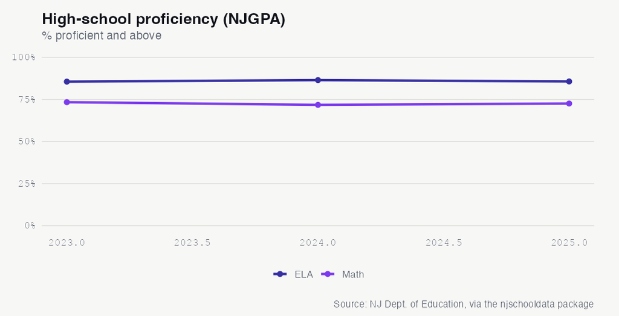

See the underlying data ›

## The Almanac

The full longitudinal record behind the stories above. Every number a reader can check.

### Enrollment (total)

| year | students | yoy | yoy_pct |
| --- | --- | --- | --- |
| 2015 | 14659 | NA | NA |
| 2016 | 15020 | 361 | 2.5 |
| 2017 | 15324 | 304 | 2 |
| 2018 | 16026 | 702 | 4.6 |
| 2019 | 16308 | 282 | 1.8 |
| 2020 | 16528 | 220 | 1.3 |
| 2021 | 16474 | -54 | -0.3 |
| 2022 | 16102 | -372 | -2.3 |
| 2023 | 16596 | 494 | 3.1 |
| 2024 | 16811 | 215 | 1.3 |
| 2025 | 16708 | -103 | -0.6 |
| 2026 | 16191 | -517 | -3.1 |

### Demographic share (%) by year

| end_year | white | black | hispanic | asian | native_american | pacific_islander | multiracial |
| --- | --- | --- | --- | --- | --- | --- | --- |
| 2015 | 19 | 8.6 | 10.5 | 60.5 | 0.2 | 0.2 | 1 |
| 2016 | 17.6 | 8.4 | 10.7 | 61.8 | 0.3 | 0.2 | 1.2 |
| 2017 | 15.8 | 8.2 | 10.7 | 63.5 | 0.4 | 0.2 | 1.2 |
| 2018 | 14.4 | 7.6 | 10.6 | 65.3 | 0.5 | 0.2 | 1.4 |
| 2019 | 13 | 7.5 | 11.2 | 66 | 0.6 | 0.2 | 1.5 |
| 2020 | 12.1 | 7.6 | 11.8 | 65.9 | 0.7 | 0.2 | 1.6 |
| 2021 | 11.3 | 7.4 | 12 | 66.6 | 0.8 | 0.2 | 1.6 |
| 2022 | 10.2 | 8 | 13.6 | 65.2 | 1 | 0.2 | 1.8 |
| 2023 | 9.7 | 8.3 | 14.1 | 64.4 | 1.1 | 0.2 | 2.2 |
| 2024 | 8.9 | 8.5 | 14.5 | 64.4 | 1.1 | 0.2 | 2.4 |
| 2025 | 8.6 | 8.8 | 15.1 | 63.7 | 1.1 | 0.1 | 2.6 |
| 2026 | 8.6 | 9 | 15.1 | 63.2 | 1.1 | 0.1 | 2.9 |

### Special populations (LEP, FRL)

| end_year | subgroup | students | pct |
| --- | --- | --- | --- |
| 2015 | lep | 354 | 2.4 |
| 2015 | free_reduced_lunch | 3216 | 21.9 |
| 2016 | lep | 305 | 2.0 |
| 2016 | free_reduced_lunch | 3036 | 20.2 |
| 2017 | lep | 384 | 2.5 |
| 2017 | free_reduced_lunch | 3205 | 20.9 |
| 2018 | lep | 433 | 2.7 |
| 2018 | free_reduced_lunch | 3278 | 20.5 |
| 2019 | lep | 407 | 2.5 |
| 2019 | free_reduced_lunch | 1597 | 9.8 |
| 2020 | lep | 446 | 2.7 |
| 2020 | free_reduced_lunch | 2595 | 15.7 |
| 2021 | lep | 527 | 3.2 |
| 2021 | free_reduced_lunch | 1993 | 12.1 |
| 2022 | lep | 660 | 4.1 |
| 2022 | free_reduced_lunch | 2496 | 15.5 |
| 2023 | lep | 863 | 5.2 |
| 2023 | free_reduced_lunch | 3435 | 20.7 |
| 2024 | lep | 1009 | 6.0 |
| 2024 | free_reduced_lunch | 4304 | 25.6 |
| 2025 | lep | 1220 | 7.3 |
| 2025 | free_reduced_lunch | 4979 | 29.8 |
| 2026 | lep | 1085 | 6.7 |
| 2026 | free_reduced_lunch | 4890 | 30.2 |

### Graduation rate 4yr (total)

| year | grad_rate | cohort |
| --- | --- | --- |
| 2020 | 93.8 | 1150 |
| 2021 | 94.2 | 1230 |
| 2022 | 94.4 | 1173 |
| 2023 | 92.8 | 1229 |
| 2024 | 92.3 | 1292 |
| 2025 | 92.1 | 1359 |

### Graduation by subgroup (2025)

| subgroup | grad_rate | cohort |
| --- | --- | --- |
| asian | 95.0 | 825 |
| female | 93.9 | NA |
| total | 92.1 | 1359 |
| white | 91.0 | 156 |
| male | 90.4 | 701 |
| economically disadvantaged | 89.0 | 480 |
| black | 87.0 | 131 |
| hispanic | 86.0 | 214 |
| students experiencing homelessness | 82.1 | 28 |
| multiracial | 80.8 | NA |
| multilingual learners | 74.7 | 79 |
| students with disabilities | 69.7 | 155 |
| american indian | NA | NA |
| migrant students | NA | NA |
| military-connected students | NA | NA |
| non-binary/undesignated gender | NA | NA |
| students in foster care | NA | NA |

### NJGPA high-school proficiency (% proficient+)

| year | test | prof_above | valid |
| --- | --- | --- | --- |
| 2023 | ela | 85.6 | 1219 |
| 2023 | math | 73.4 | 1224 |
| 2024 | ela | 86.5 | 1305 |
| 2024 | math | 71.8 | 1307 |
| 2025 | ela | 85.7 | 1220 |
| 2025 | math | 72.6 | 1224 |

### NJGPA ELA by subgroup (2025)

[output not shown]

### NJSLA grades 3-8 proficiency (% proficient+, enrollment-weighted across grades)

| testing_year | test_name | prof |
| --- | --- | --- |
| 2017 | ela | 76.2 |
| 2017 | math | 63.8 |
| 2018 | math | 64.8 |
| 2019 | ela | 76.2 |
| 2019 | math | 62.1 |
| 2022 | ela | 68.7 |
| 2022 | math | 53.5 |
| 2023 | ela | 70.7 |
| 2023 | math | 55.3 |
| 2024 | ela | 68.5 |
| 2024 | math | 53.4 |

### NJSLA ELA proficiency by subgroup (2024, grades 3-8)

| subgroup | prof |
| --- | --- |
| asian | 82.5 |
| american_indian | 79.2 |
| non_ed | 78.0 |
| female | 73.1 |
| total_population | 68.5 |
| male | 64.1 |
| FORMER - ML | 59.5 |
| other | 51.5 |
| lep_former | 47.0 |
| white | 46.4 |
| MULTILINGUAL LEARNERS | 42.1 |
| ed | 36.5 |
| hispanic | 36.0 |
| black | 35.3 |
| lep_current_former | 33.2 |
| special_education | 13.6 |
| sped_accomodations | 12.7 |
| lep_current | 6.5 |
| CURRENT - ML | 5.8 |

### Chronic absenteeism (% chronically absent)

| year | chronic_pct |
| --- | --- |
| 2019 | 5.9 |
| 2021 | 4.2 |
| 2022 | 11.5 |
| 2023 | 13 |
| 2024 | 12.1 |

### Disciplinary removals

[output not shown]

### Police notifications (incident counts)

| year | violence | weapons | vandalism | substances | hib | other |
| --- | --- | --- | --- | --- | --- | --- |
| 2019 | 7 | 0 | 1 | 4 | 0 | 0 |
| 2020 | 4 | 1 | 0 | 3 | 1 | 0 |
| 2021 | 1 | 0 | 1 | 0 | 0 | 0 |
| 2022 | 12 | 7 | 3 | 1 | 4 | 0 |
| 2023 | 9 | 4 | 2 | 1 | 14 | 1 |
| 2024 | 9 | 3 | 0 | 2 | 8 | 0 |

### HIB (harassment/intimidation/bullying) investigations

| end_year | alleged | confirmed |
| --- | --- | --- |
| 2019 | 16 | 11 |
| 2020 | 18 | 8 |
| 2021 | 3 | 2 |
| 2022 | 38 | 47 |
| 2023 | 94 | 130 |
| 2024 | 69 | 80 |

### SAT participation (% of grade)

| year | sat_part | state_sat |
| --- | --- | --- |
| 2018 | 77.4 | 72.2 |
| 2019 | 79.5 | 72.1 |
| 2020 | 75.1 | 71.1 |
| 2021 | 45.7 | 45.4 |
| 2022 | 59.3 | 60.8 |
| 2023 | 61.5 | 61.9 |
| 2024 | 57.1 | 62.7 |

### AP/IB & dual enrollment (% of students)

| year | apib_coursework | apib_exam | ap3_ib4 | state_ap3_ib4 | dual |
| --- | --- | --- | --- | --- | --- |
| 2018 | 28.3 | 26.2 | 23.2 | 20.5 | 0 |
| 2019 | 30.6 | 27.1 | 24 | 20.7 | 55.2 |
| 2020 | 28.6 | 25.1 | 22.5 | 22.8 | 54.9 |
| 2021 | 29.3 | 27.5 | 24.8 | 17.9 | 62.6 |
| 2022 | 29.2 | 27.7 | 24.3 | 19.9 | 62.2 |
| 2023 | 29.5 | 28.5 | 25.9 | 21.3 | 21.8 |
| 2024 | 31.5 | 30.5 | 26.7 | 23 | 13.4 |

### Special education (raw rows; inspect for classification rate)

| end_year | district_id |
| --- | --- |
| 2024 | 1290 |

### Per-pupil spending (TGES actuals)

| year | per_pupil | rank | ade |
| --- | --- | --- | --- |
| 2014 | 12344 | 18 | 14497 |
| 2015 | 12444 | 15 | 14697 |
| 2016 | 12270 | 9 | 15096 |
| 2017 | 12268 | 4 | 15532 |
| 2018 | 12268 | 4 | 16081 |
| 2019 | 12324 | 1 | 16344 |
| 2020 | 12736 | 2 | 16490 |
| 2021 | 13394 | 1 | 16333 |
| 2022 | 14019 | 2 | 16151 |
| 2023 | 13595 | 1 | 16645 |
| 2024 | 15247 | 3 | 16806 |

### Spending composition shares (2025)

| classroom_share | support_services_share | administration_share | plant_ops_share | food_service_share | extracurricular_share | equipment_share |
| --- | --- | --- | --- | --- | --- | --- |
| 62.5 | 15 | 9.7 | 11.1 | NA | 1.3 | 0.2 |

### Staffing ratios

| end_year | student_teacher_district | student_admin_district | student_counselor_district | student_nurse_district |
| --- | --- | --- | --- | --- |
| 2024 | 13:1 | 219:1 | 359:1 | 888:1 |

Back to top